# Unsupervised target and network analysis for CTRP and GDSC data

Wenyu

5/11/2023

This notebook explores how gene signatures of drugs help drug mechanism discovery. Rendering the notebook with pre-computed input takes around 315 seconds.

# 1 Target enrichment in top signature genes

```r
CTRP_binary_PPIold_data <- read_csv( "~/cluster_scratch/prior/CTRP_binary_PPIold_data.csv")
GDSC_binary_PPIold_data <- read_csv( "~/cluster_scratch/prior/GDSC_binary_PPIold_data.csv")
```

pick top 50, 100, 200 genes and compare to what percentage of drug the target of which can be prioritized by the top genes Figure 4A

```r
source("~/cluster_wrk/drug_moa/unsupervised_target_exploration/function/get_drug_frac.R")
target_idf <- bind_rows(
  map_dfr(
    .x = c(50, 100, 200),
    .f = ~get_drug_frac(dataset= CTRP_binary_PPIold_data, top_num=.x)) %>%
    mutate(dataset= "CTRP"),
  map_dfr(.x = c(50, 100, 200),
          .f = ~get_drug_frac(dataset= GDSC_binary_PPIold_data, top_num=.x)) %>%
    mutate(dataset= "GDSC")
) %>%
  mutate(imptype=recode(imptype, "ConExp-Sig"= "Exp-sig" , "ConSen-Sig"= "Ess-sig")) %>%
  mutate(impdef=recode(impdef, "topneg gene"= "Bottom genes" , "toppos gene"= "Top genes"))
```

```
## by 'imptype'. You can override using the `.groups` argument.`summarise()`
## has grouped output by 'imptype'. You can override using the `.groups`
## argument.`summarise()` has grouped output by 'imptype'. You can override using
```

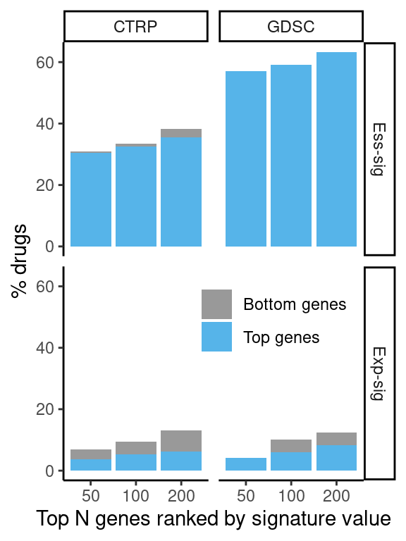

```r
# Bar plot: pos/neg stack, top_n dodge, imptype x axis, dataset facet
# seems impossible to both stack and dodge

fig <- target_idf %>%
  ggplot(aes(x= factor(top_n),y = frac, fill= impdef)) +
  geom_bar(stat = "identity",position = "stack")+
  facet_grid(cols = vars(dataset), rows = vars(imptype))+
  xlab("Top N genes ranked by signature value")+
  ylab("% drugs") +
  scale_fill_manual(values=c("#999999", "#56B4E9"))+
  theme_classic()+
  guides(fill=guide_legend(title="",nrow = 2,title.position = "top"))+
  theme(legend.position = "top")+
  theme(
    legend.position = c(0.7, 0.4),
    # legend.justification = c("left", "middle"),
    legend.box.just = "right"
    )
fig
```

```r
# ggsave(fig, filename = "~/cluster_wrk/drug_moa/unsupervised_target_exploration/fig_res/fig 4A.pdf",width = 3,height = 4)
# ggsave(fig, filename = "~/cluster_wrk/drug_moa/unsupervised_target_exploration/fig_res/fig 4A.png",width = 3,height = 4,dpi = 500)
```

quantify and test significance In contrast, drug targets were much less identified by the top or the bottom genes in the gene expression signatures

```r
CTRP_binary_PPIold_data %>%
  select(drug) %>%
  distinct() %>%
  nrow() #217
```

```
## [1] 217
```

```r
GDSC_binary_PPIold_data %>%
  select(drug) %>%
  distinct()  %>%
  nrow() #57
```

```
## [1] 57
```

```r
test_data1 <-  target_idf %>%
  filter(impdef== "Bottom genes") %>%
  mutate(dataset= "GDSC", frac=0, count=0) %>%
  bind_rows(target_idf ) %>%
  arrange(imptype, top_n, dataset,impdef) %>%
  mutate(
    # frac_notidentified= 100-frac,
    count_notidentified=case_when(
      dataset=="CTRP" ~ 217-count, dataset=="GDSC" ~ 57-count) ) %>%
  # pivot_longer(
  #   cols = one_of("frac", "frac_notidentified"),
  #   names_to="type", values_to= "perc" )
  pivot_longer(
    cols = one_of("count", "count_notidentified"),
    names_to="type", values_to= "perc" )

# impdef is not a concern here
Table1 = xtabs(perc ~ imptype +  type+ dataset,
              data=test_data1)
Table1
```

```
## , , dataset = CTRP
##
##          type
## imptype   count count_notidentified
##   Ess-sig   196                1106
##   Exp-sig    56                1246
##
## , , dataset = GDSC
##
##          type
## imptype   count count_notidentified
##   Ess-sig    88                 254
##   Exp-sig    13                 557
```

```r
mantelhaen.test(Table1,exact = T) # fisher exact test
```

```
##
##  Exact conditional test of independence in 2 x 2 x k tables
##
## data:  Table1
## S = 284, p-value < 2.2e-16
## alternative hypothesis: true common odds ratio is not equal to 1
## 95 percent confidence interval:
##  4.302749 7.600074
## sample estimates:
## common odds ratio
##          5.686715
```

As shown in Figure 4A, many drugs had their primary targets enriched in their top essentiality signatures genes(Fisher’test P = 1.2e-07). For example, the primary targets for 30.4% of CTRP drugs and 57.1% of GDSC drugs were found within the top 50 genes in the gene essentiality signatures. The primary targets showed no enrichment in bottom genes (Fisher’test P > 0.05) in the gene essentiality signatures.

```r
test_data2 <- target_idf %>%
  filter(imptype=="Ess-sig") %>%
  filter(impdef== "Bottom genes") %>%
  mutate(dataset= "GDSC", frac=0, count=0) %>%
  bind_rows(target_idf %>% filter(imptype=="Ess-sig")) %>%
  arrange(imptype, top_n, dataset,impdef) %>%
  mutate(
    # frac_notidentified= 100-frac,
    count_notidentified=case_when(
      dataset=="CTRP" ~ 217-count, dataset=="GDSC" ~ 57-count) ) %>%
  # pivot_longer(
  #   cols = one_of("frac", "frac_notidentified"),
  #   names_to="type", values_to= "perc" )
  pivot_longer(
    cols = one_of("count", "count_notidentified"),
    names_to="type", values_to= "perc" )

Table2 = xtabs(perc ~  impdef + type+dataset,
              data=test_data2)
mantelhaen.test(Table2)
```

```
##
##  Mantel-Haenszel chi-squared test with continuity correction
##
## data:  Table2
## Mantel-Haenszel X-squared = 307.05, df = 1, p-value < 2.2e-16
## alternative hypothesis: true common odds ratio is not equal to 1
## 95 percent confidence interval:
##  0.01038970 0.04159681
## sample estimates:
## common odds ratio
##         0.0207889
```

```r
rcompanion::groupwiseCMH(Table2, group=1, fisher=T)
```

```
##          Group   Test  p.value    adj.p
## 1 Bottom genes Fisher 2.16e-01 2.16e-01
## 2    Top genes Fisher 5.94e-08 1.19e-07
```

```r
# Instead I want to focus only on Ess

188/(188+8)
```

```
## [1] 0.9591837
```

```r
Table2
```

```
## , , dataset = CTRP
##
##               type
## impdef         count count_notidentified
##   Bottom genes     8                 643
##   Top genes      188                 463
##
## , , dataset = GDSC
##
##               type
## impdef         count count_notidentified
##   Bottom genes     0                 171
##   Top genes       88                  83
```

```r
# hypergeometric test whether target is enriched in the top or bottom
```

ROC and AUC Figure 4B-4C

```r
source("~/cluster_wrk/drug_moa/unsupervised_target_exploration/function/plot_ave_roc.R")

tmp <- CTRP_binary_PPIold_data %>%
    mutate(imptype= recode(imptype,
                           "ConExp-Sig"= "exp-sig" , "ConSen-Sig"= "ess-sig"))

pdf("~/cluster_wrk/drug_moa/unsupervised_target_exploration/fig_res/fig 4b.pdf",width = 3.25,height = 3.25)
par(mar=c(4.5,4.5,0.5,0.5))
plot_ave_roc(
  annotated_pred_df = CTRP_binary_PPIold_data %>%
    mutate(imptype=recode(imptype, "ConExp-Sig"= "Exp-sig" , "ConSen-Sig"= "Ess-sig")) ,
  addlegend = T
  )
```

```
##   method         from
##   reorder.factor DescTools
```

```r
dev.off()
```

```r
pdf("~/cluster_wrk/drug_moa/unsupervised_target_exploration/fig_res/fig 4c.pdf",width = 3.25,height = 3.25)
par(mar=c(4.5,4.5,0.5,0.5))
plot_ave_roc(
  annotated_pred_df =
    GDSC_binary_PPIold_data %>%
    mutate(imptype=recode(imptype, "ConExp-Sig"= "Exp-sig" , "ConSen-Sig"= "Ess-sig")),
  addlegend = T)
```

```
## argument.Joining, by = c("drug", "imptype")
```

```r
dev.off()
```

```
## argument.Joining, by = c("drug", "imptype")
```

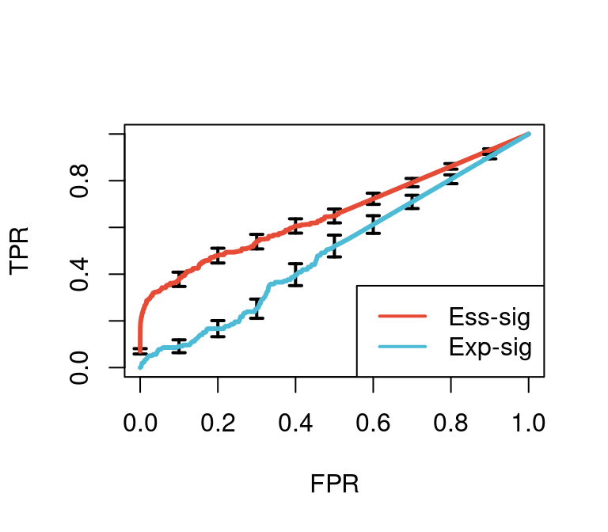

```r
plot_ave_roc(
  annotated_pred_df = CTRP_binary_PPIold_data %>%
    mutate(imptype=recode(imptype, "ConExp-Sig"= "Exp-sig" , "ConSen-Sig"= "Ess-sig")) ,
  addlegend = T
  )
```

```
## argument.Joining, by = c("drug", "imptype")
```

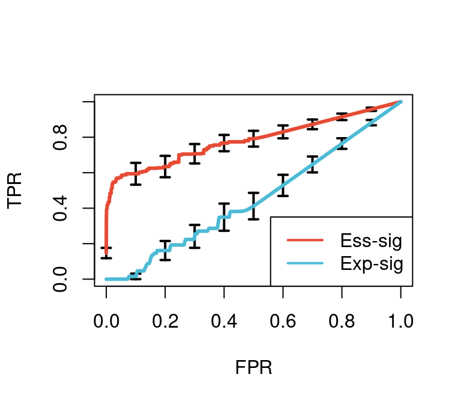

```r
plot_ave_roc(
  annotated_pred_df =
    GDSC_binary_PPIold_data %>%
    mutate(imptype=recode(imptype, "ConExp-Sig"= "Exp-sig" , "ConSen-Sig"= "Ess-sig")),
  addlegend = T)
```

Supplementary figure 3

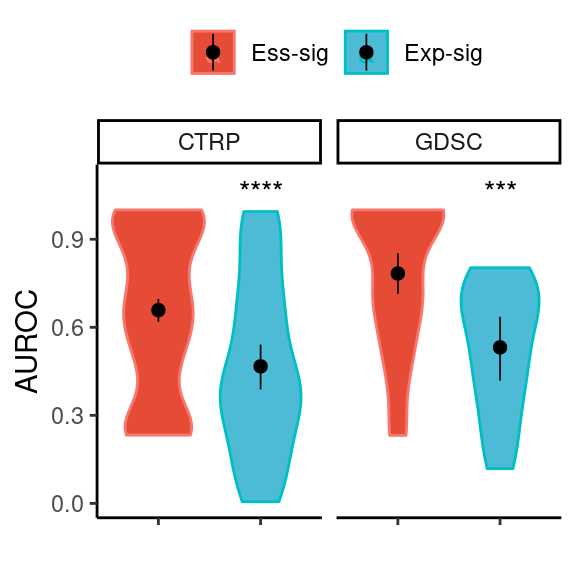

```r
load("~/cluster_scratch/unsupervised_target_pred/unsupervised_target_pred_method_comparison.RData")
auc_df <-
  bind_rows(
      ctrp_unsupervised_auc %>% select(-drug) %>% mutate(dataset= "CTRP"),
      gdsc_unsupervised_auc %>% select(-drug) %>% mutate(dataset= "GDSC")
) %>%
    mutate(imptype= recode(imptype,
                           "ConExp-Sig"= "Exp-sig" , "ConSen-Sig"= "Ess-sig"))

fig <- auc_df %>%
  drop_na() %>%
  ggplot(aes(x=imptype, y=AUC,fill= imptype, color= imptype)) +
  geom_violin()+
  ggpubr::stat_compare_means(
    aes(group=imptype),
    label = "p.signif",label.y = 1.1,
    method = "t.test",vjust = 1,ref.group = "Ess-sig")+
  stat_summary(fun.data = "mean_cl_boot", geom = "pointrange",
           colour = "black",size=0.3)+
  facet_wrap(~dataset)+
  theme_classic()+
  theme(axis.text.x = element_blank())+
  xlab(label = "")+
  ylab(label = "AUROC")+
  guides(fill=guide_legend(nrow = 1))+
  theme(legend.title = element_blank(),legend.position = "top")+
  # scale_color_manual(name="Cylinders",
  #                  labels=c("ConSen-sig", "ConExp-sig", "Fingerprint-ECFP","Fingerprint-MACCS" ))+
  scale_fill_npg()
fig
```

```r
ggsave(fig, filename = "~/cluster_wrk/drug_moa/unsupervised_target_exploration/fig_res/supplementary figure1.pdf",width = 3,height = 3,bg= "transparent")
ggsave(fig, filename = "~/cluster_wrk/drug_moa/unsupervised_target_exploration/fig_res/supplementary figure1.png",width = 3,height = 3,dpi = 500,bg= "transparent")
```

```r
auc_df %>%
  group_by(imptype, dataset) %>%
  summarize(AUC_ave=round(mean(AUC, na.rm=T),2))
```

```
## # A tibble: 4 × 3
## # Groups:   imptype [2]
##   imptype dataset AUC_ave
##   <chr>   <chr>     <dbl>
## 1 Ess-sig CTRP       0.66
## 2 Ess-sig GDSC       0.78
## 3 Exp-sig CTRP       0.47
## 4 Exp-sig GDSC       0.53
```

```r
sig_res1 <- auc_df %>%
  nest_by(dataset) %>%
  ungroup() %>%
  mutate(test_res= map(
    .x = data,
    .f = function(df){
      res= t.test(df$AUC~df$imptype)
      res= res%>% broom::tidy()}
                         ))
```

# 2 Target neigbouring gene enrichment in top signature genes

Supplementary figure4

```r
network_idf <- bind_rows(
  get_drug_frac(dataset= CTRP_binary_PPIold_data, top_n=50, res_type = "druglevel") %>%
    mutate(dataset= "CTRP") %>%  select(-drug) ,
  get_drug_frac(dataset= GDSC_binary_PPIold_data, top_n=50, res_type = "druglevel") %>%
    mutate(dataset= "GDSC") %>%  select(-drug) ) %>%
    mutate(impdef=recode(impdef, "topneg gene"= "Bottom genes" , "toppos gene"= "Top genes")) %>%
    mutate(imptype=recode(imptype, "ConExp-Sig"= "Exp-sig" , "ConSen-Sig"= "Ess-sig"))
```

```r
fig <- network_idf %>%
  group_by(dataset,imptype) %>%
  mutate(num= n()) %>%
  mutate(anno_type2 = case_when(
             anno_type2 <1 ~ "Target",
             between(anno_type2,1,2) ~as.character(anno_type2),
             anno_type2>2 ~ "over 2")) %>%
  ungroup() %>%
  group_by(impdef, anno_type2,dataset, imptype) %>%
  summarize(perc= n()/num*100) %>%
  ungroup() %>% distinct() %>%
  mutate(anno_type2= factor(anno_type2,c("Target", "1", "2", "over 2"))) %>%
  ggplot(aes(x= anno_type2,y=perc, fill= impdef)) +
  geom_bar(stat = "identity",position = "stack")+
  facet_grid(cols = vars(dataset), rows = vars(imptype))+
  xlab("Gene category by PPI target network")+
  ylab("% drugs")  +
    scale_fill_manual(values=c("#999999", "#56B4E9"))+
  theme_classic()+
  guides(fill=guide_legend(nrow = 1))+
  theme(legend.title= element_blank(), legend.position = "top")
```

```
## 'imptype'. You can override using the `.groups` argument.
```

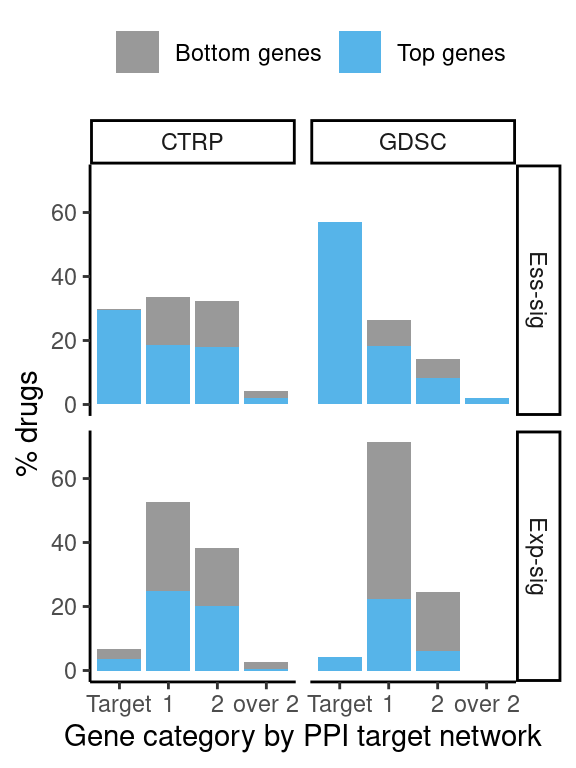

```r
  # theme(
  #   legend.position = c(0.2, 0.90)
  #   # legend.justification = c("left", "middle"),
  #   # legend.box.just = "right"
  #   )

fig
```

```r
ggsave(fig, filename = "~/cluster_wrk/drug_moa/unsupervised_target_exploration/fig_res/supplementary figure2.png",width = 3,height = 4,dpi = 500,bg= "transparent")
ggsave(fig, filename = "~/cluster_wrk/drug_moa/unsupervised_target_exploration/fig_res/supplementary figure2.pdf",width = 3,height = 4,bg= "transparent")
```

Find one drug for story telling (for figure 4D) From CTRP and GDSC for a list of drugs where unsupervised AUC=1, output their nominal target, their top 5 positive and negative gene

```r
ctrp_bestranked_drugs <- ctrp_unsupervised_auc %>%  filter(imptype=="ConSen-Sig") %>% filter(AUC == 1) %>% pull(drug)
gdsc_bestranked_drugs <- gdsc_unsupervised_auc %>%  filter(imptype=="ConSen-Sig") %>% filter(AUC == 1) %>% pull(drug)

# get top gene table
tmp <- bind_rows(
  get_drug_frac(dataset= CTRP_binary_PPIold_data, top_n=5, res_type = "toppair",top_method ="top_both" ) %>%
    mutate(dataset= "CTRP") %>%  filter(drug %in% ctrp_bestranked_drugs) ,
  get_drug_frac(dataset= GDSC_binary_PPIold_data, top_n=5, res_type = "toppair",top_method ="top_both") %>%
    mutate(dataset= "GDSC") %>%  filter(drug %in% gdsc_bestranked_drugs) %>% mutate(drug= as.character(drug))
) %>%
  filter(imptype== "ConSen-Sig") %>%
  group_by(drug) %>%
  arrange(desc(imp),.by_group=T )
# write_csv(tmp, "~/cluster_wrk/drug_moa/unsupervised_target_exploration/findacase_featureimp.csv")

# get meta table
load("~/cluster_scratch/forward_modelling/targetpred_output_simplefiltering.RData")
tmp1 <- ctrp_data %>% select_at(c(1,4,5)) %>% filter(broad_cpd_id %in% ctrp_bestranked_drugs)
colnames(tmp1) <- c("MOA", "DRUG_NAME", "DRUG_ID")
tmp2 <- gdsc_data %>% filter(DRUG_ID %in% gdsc_bestranked_drugs) %>%
  rename(MOA= PATHWAY_NAME) %>%
  mutate(DRUG_ID= as.character(DRUG_ID)) %>%
  select(MOA, DRUG_NAME, DRUG_ID)
tmp3 <- bind_rows(tmp1, tmp2)
# write_csv(tmp3, "~/cluster_wrk/drug_moa/unsupervised_target_exploration/findacase_drugmeta.csv")

tmp4 <- inner_join(tmp, tmp3,by=c("drug"= "DRUG_ID"))
# write_csv(tmp4, "~/cluster_wrk/drug_moa/unsupervised_target_exploration/findacase_combined.csv")
```

a gene-level summary

```r
tmp <- read_csv("~/cluster_wrk/drug_moa/unsupervised_target_exploration/findacase_combined.csv")

top_pos <-
  inner_join(
      tmp %>% filter(impdef=="toppos gene") %>%
        select(DRUG_NAME, gene) %>%
        distinct() %>%
        group_by(gene) %>%
        summarize(drug_associated= paste(sort(DRUG_NAME), collapse = ";" ),
                  NO.associated_Drugs=n()) %>%
        ungroup()
      ,
      tmp %>% filter(impdef=="toppos gene") %>%
        select(gene, MOA) %>%
        distinct() %>%
        group_by(gene) %>%
        summarize(MOA= paste(sort(MOA), collapse = ";" )) %>%
        ungroup()

      )

top_pos_target <- tmp %>%
  filter(impdef=="toppos gene") %>%
  filter(anno_type=="Target") %>%
  select(gene, DRUG_NAME) %>%
  group_by(gene) %>%
  summarize(drug_targeted= paste(sort(DRUG_NAME), collapse = ";" ), NO.Targeted_Drugs=n()) %>%
        ungroup()

top_pos_gene_df <- left_join(top_pos, top_pos_target)  %>% arrange(desc(NO.associated_Drugs))

top_neg_gene_df <- inner_join(
  tmp %>% filter(impdef=="topneg gene") %>%
        select(DRUG_NAME, gene) %>%
        distinct() %>%
        group_by(gene) %>%
        summarize(drug_associated= paste(sort(DRUG_NAME), collapse = ";" ),
                  NO.associated_Drugs=n()
                  )
        ,
      tmp %>% filter(impdef=="topneg gene") %>%
        select(gene, MOA) %>%
        distinct() %>%
        group_by(gene) %>%
        summarize(MOA= paste(sort(MOA), collapse = ";" )) %>%
        ungroup()
) %>%
  arrange(desc(NO.associated_Drugs))

# write_csv(top_pos_gene_df,"~/cluster_wrk/drug_moa/unsupervised_target_exploration/gene-level summary(top pos).csv")
# write_csv(top_neg_gene_df, "~/cluster_wrk/drug_moa/unsupervised_target_exploration/gene-level summary(top neg).csv")
```

one drug lapatinib seems to be a good example for story telling. Get the top10 and bottom 10 genes for the drug.

1558 Lapatinib BRD-K19687926

```r
Lapatinib <-
bind_rows(
GDSC_binary_PPIold_data %>% filter(drug == "1558") %>% filter(imptype=="ConSen-Sig" ) %>% arrange(desc(imp)) %>%  slice(1:10, 10614:10623)%>% mutate(drug=as.character(drug))
,
CTRP_binary_PPIold_data %>% filter(drug == "BRD-K19687926") %>% filter(imptype=="ConSen-Sig" ) %>% arrange(desc(imp))%>%  slice(1:10, 10614:10623)

) %>%
  mutate(direction= case_when(imp>0~"POS", imp<0~"NEG")) %>%
  group_by(drug, direction) %>%
  mutate(gene_rank= rank(desc(abs(imp))) ) %>%
  ungroup() %>%
  group_by(gene) %>%
  mutate(freq=n()) %>%
  ungroup() %>%
  select(gene, dataset, gene_rank, direction,freq)
  # pivot_wider(id_cols = gene, names_from= dataset, values_from= gene_rank) %>%
  # arrange(CTRP)

# write_csv(Lapatinib, "Lapatinib.csv")
```

## 3 pathway analysis

```r
load("~/cluster_scratch/forward_modelling/targetpred_output_simplefiltering.RData")
load("~/cluster_scratch/glmnet_modelling/target_pred_server/res_pathway_all.RData")
ctrp_allvalid_list <- res_ctrp2 %>%
  select(-.metric, -estimate, -variance, -input) %>%
  distinct() %>%
  filter(!sample_size <100) %>%
  filter(!drug_pair) %>%
  select(cpd_smiles,broad_cpd_id, sample_size) %>%
  drop_na() %>%
  group_by(cpd_smiles) %>%
  slice_max(n=1, order_by=sample_size) %>%
  pull(broad_cpd_id)

#n= 175
gdsc_allvalid_list <- res_gdsc2 %>%
  select(-.metric, -estimate, -variance, -input) %>%
  distinct() %>%
  filter(!sample_size <100) %>%
  # select(smiles,DRUG_ID, sample_size) %>%
  # drop_na() %>%
  group_by(DRUG_NAME) %>%
  slice_max(n=1, order_by=sample_size) %>%
  pull(DRUG_ID)

pathways_df_gdsc <-
  tibble(drug=feature_imp_ridge_gdsc_comb1$drug, pathway=gdsc_kegg) %>%
  unnest()%>%
  arrange(padj) %>%
  inner_join(y = gdsc_data %>% select_at(1:4),
             by= c("drug"= "DRUG_ID")) %>%
  # select(-log2err, -ES, -pval, -leadingEdge,-NES, -size) %>%
  select(-log2err, -leadingEdge, -size) %>%
  # filter(pathway %in% c("KEGG_MAPK_SIGNALING_PATHWAY","KEGG_MISMATCH_REPAIR", "KEGG_ERBB_SIGNALING_PATHWAY")) %>%
  filter(padj<0.05) %>%
  # select(pathway, padj, DR)
  filter(drug %in% gdsc_allvalid_list)
  # filter(DRUG_NAME %in% c("Axitinib")) #"Osimertinib"))#, "MK-1775") )

#
# options(scipen = 3)
example_gdsc_DDR <- pathways_df_gdsc %>%
  filter(pathway %in% c("KEGG_MISMATCH_REPAIR")) %>%
  select(-drug) %>%
  rename(REPORTED_MECHANISM=PATHWAY_NAME) %>%
  select(-pval) %>%
  filter(NES>1.5) %>%
  arrange(padj) %>%
  mutate(padj= formatC(padj, format = "e", digits = 2),
         ES= round(ES,2), NES=round(NES, 2))

pathways_df_ctrp <- tibble(drug=feature_imp_ridge_ctrp_comb1$drug, pathway=ctrp_kegg) %>%
  unnest()%>%
  arrange(padj) %>%
  inner_join(
    y = ctrp_data %>% filter(drug_type== "single drug") %>% select_at(c(1,4,5)),
    by= c("drug"= "broad_cpd_id")) %>%
  select(-log2err, -leadingEdge,  -size) %>%
  filter(drug %in% ctrp_allvalid_list) %>%
  filter(padj<0.05)

example_ctrp_DDR <- pathways_df_ctrp %>%
  filter(pathway %in% c("KEGG_MISMATCH_REPAIR")) %>%
  select(-drug) %>%
  rename(REPORTED_MECHANISM=target_or_activity_of_compound) %>%
  mutate(padj= formatC(padj, format = "e", digits = 2),
         ES= round(ES,2), NES=round(NES, 2))

pathways_df_prism <-
  tibble(drug=feature_imp_ridge_prism_comb1$drug, pathway=prism_kegg) %>%
  unnest()%>%
  arrange(padj) %>%
  inner_join(y = prism_data %>% select_at(1:4),
             by= c("drug"= "BROAD_ID")) %>%
  select(-log2err, -leadingEdge, -size) %>%
  filter(padj<0.05)

write_csv(pathways_df_gdsc, "pathways_df_gdsc.csv")
write_csv(pathways_df_ctrp, "pathways_df_ctrp.csv")
write_csv(pathways_df_prism, "pathways_df_prism.csv")


write_csv(example_gdsc_DDR, "pathway_example_gdsc_DDR.csv")
write_csv(example_ctrp_DDR, "pathway_example_ctrp_DDR.csv")


GO_df_gdsc <-
  tibble(drug=feature_imp_ridge_gdsc_comb1$drug, pathway=gdsc_go) %>%
  unnest()%>%
  arrange(padj) %>%
  inner_join(y = gdsc_data %>% select_at(1:4),
             by= c("drug"= "DRUG_ID")) %>%
  select(-log2err,  -leadingEdge, -size) %>%
  filter(padj<0.05)

GO_df_ctrp <-
  tibble(drug=feature_imp_ridge_ctrp_comb1$drug, pathway=ctrp_go) %>%
  unnest()%>%
  arrange(padj) %>%
  inner_join(y = ctrp_data %>% filter(drug_type== "single drug") %>% select_at(c(1,4,5)),
             by= c("drug"= "broad_cpd_id")) %>%
  select(-log2err, -pval, -leadingEdge,  -size) %>%
  filter(padj<0.05)


GO_df_prism <-
  tibble(drug=feature_imp_ridge_prism_comb1$drug, pathway=prism_go) %>%
  unnest()%>%
  arrange(padj) %>%
  inner_join(y = prism_data %>% select_at(1:4),
             by= c("drug"= "BROAD_ID")) %>%
  select(-log2err, -leadingEdge,  -size) %>%
  filter(padj<0.05)

write_csv(GO_df_gdsc, "GO_df_gdsc.csv")
write_csv(GO_df_prism, "GO_df_prism.csv")
write_csv(GO_df_ctrp, "GO_df_ctrp.csv")

example_gdsc_DDR
```

```
## # A tibble: 9 × 7
##   pathway              padj        ES   NES DRUG_NAME REPORTED_MECHAN… DRUG_TYPE
##   <chr>                <chr>    <dbl> <dbl> <chr>     <chr>            <chr>
## 1 KEGG_MISMATCH_REPAIR 6.11e-05  0.75  2.4  AZD7762   Cell cycle       Targeted
## 2 KEGG_MISMATCH_REPAIR 4.95e-04  0.71  2.21 MK-8776   Cell cycle       Targeted
## 3 KEGG_MISMATCH_REPAIR 1.24e-03  0.71  2.26 Wee1 Inh… Cell cycle       Targeted
## 4 KEGG_MISMATCH_REPAIR 2.97e-03  0.67  2.07 MK-1775   Cell cycle       Targeted
## 5 KEGG_MISMATCH_REPAIR 3.40e-03  0.7   2.17 Talazopa… Genome integrity Targeted
## 6 KEGG_MISMATCH_REPAIR 8.53e-03  0.64  2.05 AZD6738   Genome integrity Targeted
## 7 KEGG_MISMATCH_REPAIR 8.54e-03  0.66  2.04 VE-822    Genome integrity Targeted
## 8 KEGG_MISMATCH_REPAIR 3.51e-02  0.61  1.96 Cytarabi… Other            Chemothe…
## 9 KEGG_MISMATCH_REPAIR 4.18e-02  0.62  1.95 Irinotec… DNA replication  Chemothe…
```